# Distance

2022-11-29

## Distance

- Many of the analyses we perform with high-dimensional data relate directly or indirectly to distance.
- Most clustering and machine learning techniques rely on being able to define distance between observations, using features or predictors.

## Euclidean distance

- As a review, let’s define the distance between two points, \(A\) and \(B\), on a Cartesian plane.

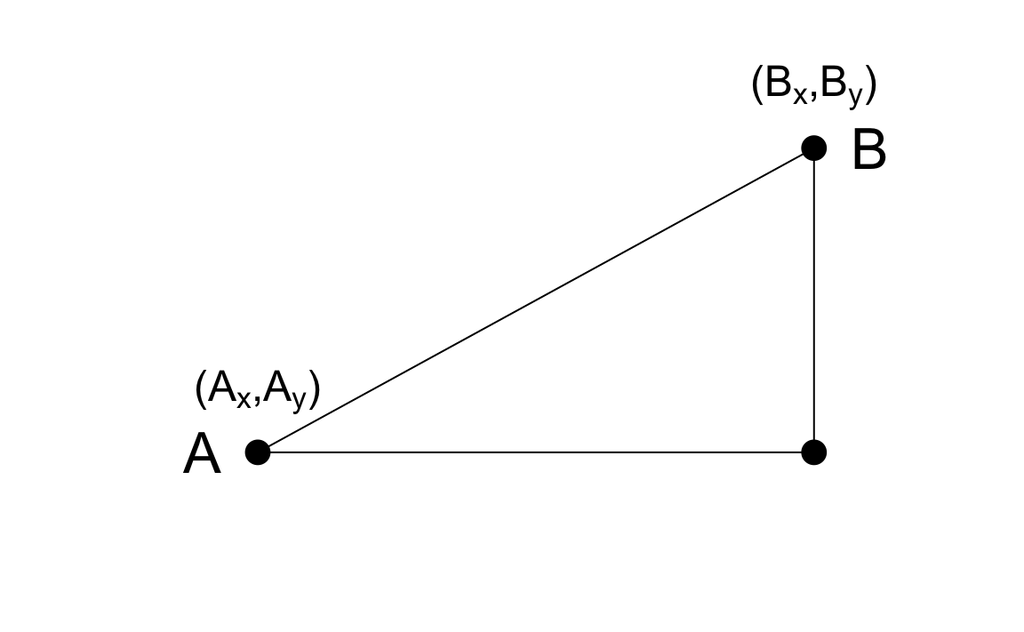

- The Euclidean distance between \(A\) and \(B\) is simply:

\[ \mbox{dist}(A,B) = \sqrt{ (A_x-B_x)^2 + (A_y-B_y)^2} \]

## Euclidean distance

- This definition applies to the case of one dimension, in which the distance between two numbers is simply the absolute value of their difference.
- So if our two one-dimensional numbers are \(A\) and \(B\), the distance is:

\[ \mbox{dist}(A,B) = \sqrt{ (A - B)^2 } = | A - B | \]

## Distance in higher dimensions

- Earlier we introduced a training dataset with feature matrix measurements for 784 features.
- For illustrative purposes, we will look at a random sample of 2s and 7s.

```r
library(tidyverse)
library(dslabs)
if(!exists("mnist")) mnist <- read_mnist()
set.seed(1995)
ind <- which(mnist$train$labels %in% c(2,7)) |> sample(500)
x <- mnist$train$images[ind,]
y <- mnist$train$labels[ind]
```

- The predictors are in `x` and the labels in `y`.

## Distance in higher dimensions

- For the purposes of, for example, smoothing, we are interested in describing distance between observation; in this case, digits.
- Later, for the purposes of selecting features, we might also be interested in finding pixels that *behave similarly* across samples.
- To define distance, we need to know what *points* are since mathematical distance is computed between points.
- With high dimensional data, points are no longer on the Cartesian plane.

## Distance in higher dimensions

- Instead, points are in higher dimensions.
- We can no longer visualize them and need to think abstractly.
- For example, predictors \(\mathbf{X}_i\) are defined as a point in 784 dimensional space: \(\mathbf{X}_i = (x_{i,1},\dots,x_{i,784})^\top\).
- Once we define points this way, the Euclidean distance is defined very similarly as it was for two dimensions.

## Distance in higher dimensions

- For example, the distance between the predictors for two observations, say observations \(i=1\) and \(i=2\), is:

\[ \mbox{dist}(1,2) = \sqrt{ \sum_{j=1}^{784} (x_{1,j}-x_{2,j })^2 } \]

- This is just one non-negative number, just as it is for two dimensions.

## Euclidean distance example

- The labels for the first three observations are:

```r
y[1:3]
```

```
#> [1] 7 2 7
```

- The vectors of predictors for each of these observations are:

```r
x_1 <- x[1,]
x_2 <- x[2,]
x_3 <- x[3,]
```

- The first and third numbers are sevens and the second one is a two.

## Euclidean distance example

```r
sqrt(sum((x_1 - x_2)^2))
```

```
#> [1] 3273
```

```r
sqrt(sum((x_1 - x_3)^2))
```

```
#> [1] 2311
```

```r
sqrt(sum((x_2 - x_3)^2))
```

```
#> [1] 2636
```

- As expected, the 7s are closer to each other.

## Euclidean distance example

- A faster way to compute this is using matrix algebra:

```r
sqrt(crossprod(x_1 - x_2))
```

```
#>      [,1]
#> [1,] 3273
```

```r
sqrt(crossprod(x_1 - x_3))
```

```
#>      [,1]
#> [1,] 2311
```

```r
sqrt(crossprod(x_2 - x_3))
```

```
#>      [,1]
#> [1,] 2636
```

## Euclidean distance example

- We can also compute **all** the distances at once relatively quickly using the function `dist`, which computes the distance between each row and produces an object of class `dist`:

```r
d <- dist(x)
class(d)
```

```
#> [1] "dist"
```

- There are several machine learning related functions in R that take objects of class `dist` as input.
- To access the entries using row and column indices, we need to coerce it into a matrix.

## Euclidean distance example

- We can see the distance we calculated above like this:

```r
as.matrix(d)[1:3,1:3]
```

```
#>      1    2    3
#> 1    0 3273 2311
#> 2 3273    0 2636
#> 3 2311 2636    0
```

- We can quickly see an image of these distances using this code:

```r
image(as.matrix(d))
```

[output not shown]

## Euclidean distance example

- If we order this distance by the labels, we can see that, in general, the twos are closer to each other and the sevens are closer to each other:

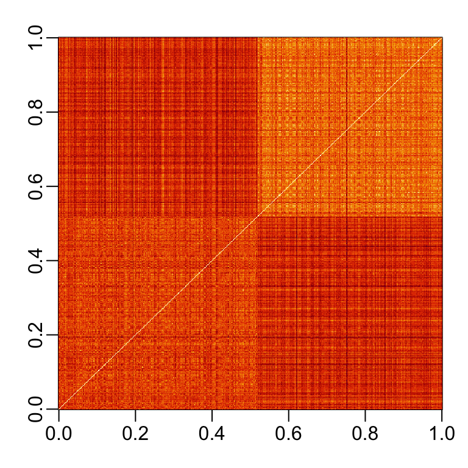

```r
image(as.matrix(d)[order(y), order(y)])
```

## Predictor space

- *Predictor space* is a concept that is often used to describe machine learning algorithms.
- The term *space* refers to a mathematical definition that we don’t describe in detail here.
- Instead, we provide a simplified explanation to help understand the term predictor space when used in the context of machine learning algorithms.
- The predictor space can be thought of as the collection of all possible vectors of predictors that should be considered for the machine learning challenge in question.

## Predictor space

- Each member of the space is referred to as a *point*.
- For example, in the 2 or 7 dataset, the predictor space consists of all pairs \((x_1, x_2)\) such that both \(x_1\) and \(x_2\) are within 0 and 1.
- This particular *space* can be represented graphically as a square.
- In the MNIST dataset the predictor space consists of all 784-th dimensional vectors with each vector element an integer between 0 and 256.

## Predictor space

- An essential element of a predictor space is that we need to define a function that provides the distance between any two points.
- In most cases we use Euclidean distance, but there are other possibilities.
- A particular case in which we can’t simply use Euclidean distance is when we have categorical predictors.
- Defining a predictor space is useful in machine learning because we do things like define neighborhoods of points, as required by many smoothing techniques.

## Predictor space

- For example, we can define a neighborhood as all the points that are within 2 units away from a predefined center.
- If the points are two-dimensional and we use Euclidean distance, this neighborhood is graphically represented as a circle with radius 2.
- In three dimensions the neighborhood is a sphere.
- We learned about algorithms that partition the space into non-overlapping regions and then make different predictions for each region using the data in the region.

## Distance between predictors

- We can also compute distances between predictors.
- If \(N\) is the number of observations, the distance between two predictors, say 1 and 2, is:

\[ \mbox{dist}(1,2) = \sqrt{ \sum_{i=1}^{N} (x_{i,1}-x_{i,2})^2 } \]

## Distance between predictors

- To compute the distance between all pairs of the 784 predictors, we can transpose the matrix first and then use `dist`:

```r
d <- dist(t(x))
dim(as.matrix(d))
```

```
#> [1] 784 784
```

## Distance between predictors

```r
d_492 <- as.matrix(d)[492,]
```

## Distance between predictors

- We can now see the spatial pattern of these distances with the code below.

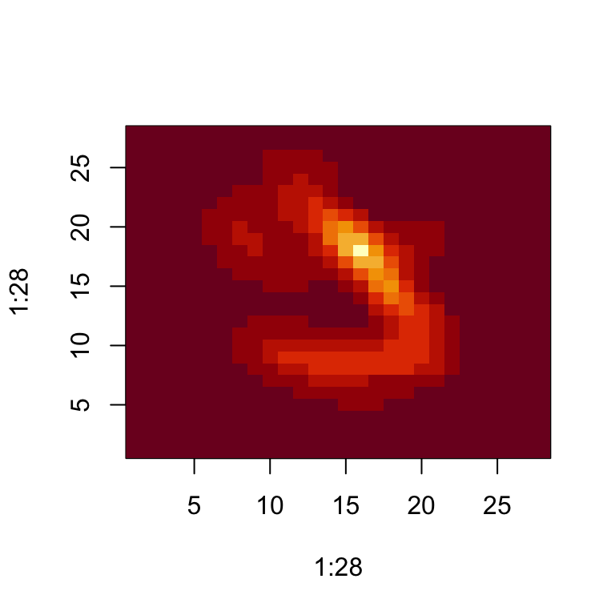

```r
image(1:28, 1:28, matrix(d_492, 28, 28))
```